```r
> library(dplyr)
> library(ggplot2)
> library(readr)
> library(NanoStringQCPro)
>
> metadata = data.frame(fname = list.files("rcc", pattern = "*.RCC")) %>% tidyr::separate(fname,
+     c("date", "id", "sample", "trash"), sep = "_", remove = FALSE) %>% select(fname,
+     sample) %>% mutate(sample = gsub(" ", "", sample)) %>% left_join(read_csv("metadata/samples.csv",
+     col_names = c("sample", "condition")), by = "sample")
> rccFiles = paste("rcc/", metadata$fname, sep = "")
> eset = newRccSet(rccFiles = rccFiles)
> colnames(eset) = metadata$sample
> rownames(metadata) = metadata$sample
> # set seed to be reproduciblish
> set.seed(12345)
```

# Imaging QC

The samples look fine in terms of the area imaged on each cartridge.

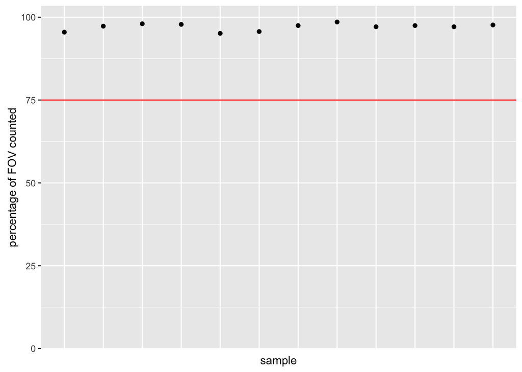

```r
> plotFOV = function(eset, metadata) {
+     pdat = pData(eset) %>% tibble::rownames_to_column() %>% left_join(metadata,
+         by = c(rowname = "sample"))
+     pdat$pcounted = pdat$FovCounted/pdat$FovCount * 100
+     ggplot(pdat, aes(rowname, pcounted)) + geom_point() + theme(axis.text.x = element_blank(),
+         axis.ticks.x = element_blank(), strip.text.x = element_text(size = 8)) +
+         scale_y_continuous(expand = c(0, 0)) + expand_limits(y = c(0, 1.05 *
+         max(pdat$pcounted))) + ylab("percentage of FOV counted") + xlab("sample") +
+         geom_hline(yintercept = 75, color = "red")
+ }
> plotFOV(eset, metadata)
```

# Binding density

The binding density is within the acceptable limits, but barely for a few of the samples. There may be quality differences between the samples despite not being technically out of the acceptable binding density range.

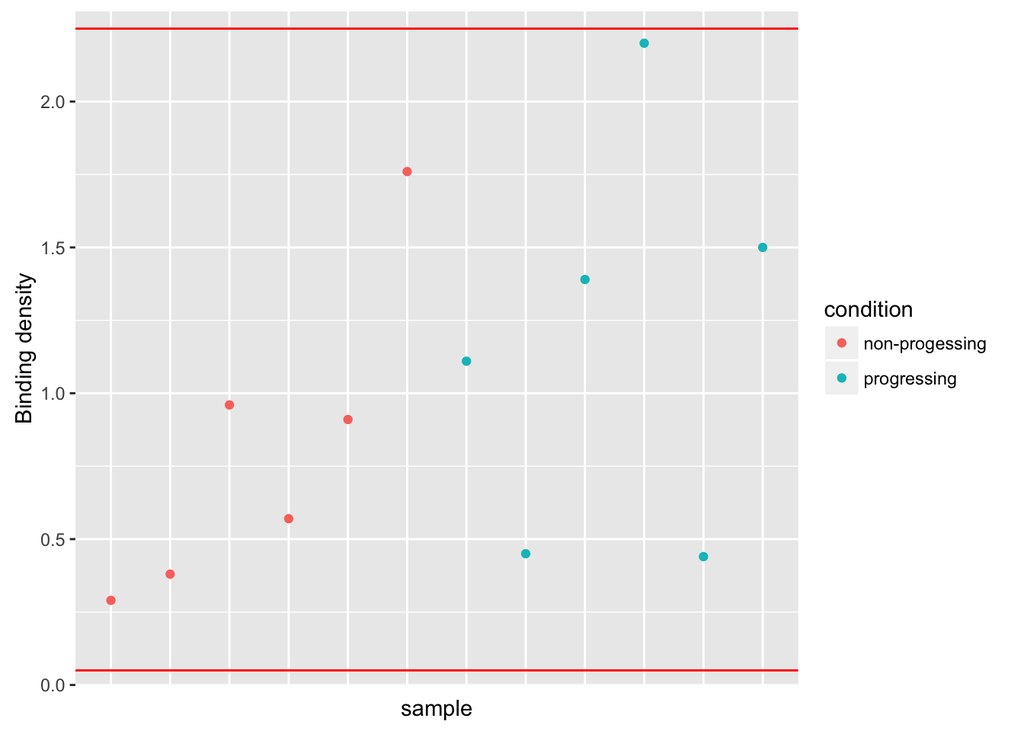

```r
> plotBD = function(eset, metadata) {
+     pdat = pData(eset) %>% tibble::rownames_to_column() %>% left_join(metadata,
+         by = c(rowname = "sample"))
+     pdat$pcounted = pdat$FovCounted/pdat$FovCount * 100
+     ggplot(pdat, aes(rowname, BindingDensity, color = condition)) + geom_point() +
+         theme(axis.text.x = element_blank(), axis.ticks.x = element_blank(),
+             strip.text.x = element_text(size = 8)) + scale_y_continuous(expand = c(0,
+         0)) + expand_limits(y = c(0, 1.05 * max(pdat$BindingDensity))) + ylab("Binding density") +
+         xlab("sample") + geom_hline(yintercept = 0.05, color = "red") + geom_hline(yintercept = 2.25,
+         color = "red")
+ }
> plotBD(eset, metadata)
```

# Total counts vs mRNA detected

We can see that some of the samples, we haven’t saturated mRNA detection. There isn’t a systematic difference between the progressive/non-progressing tumors however.

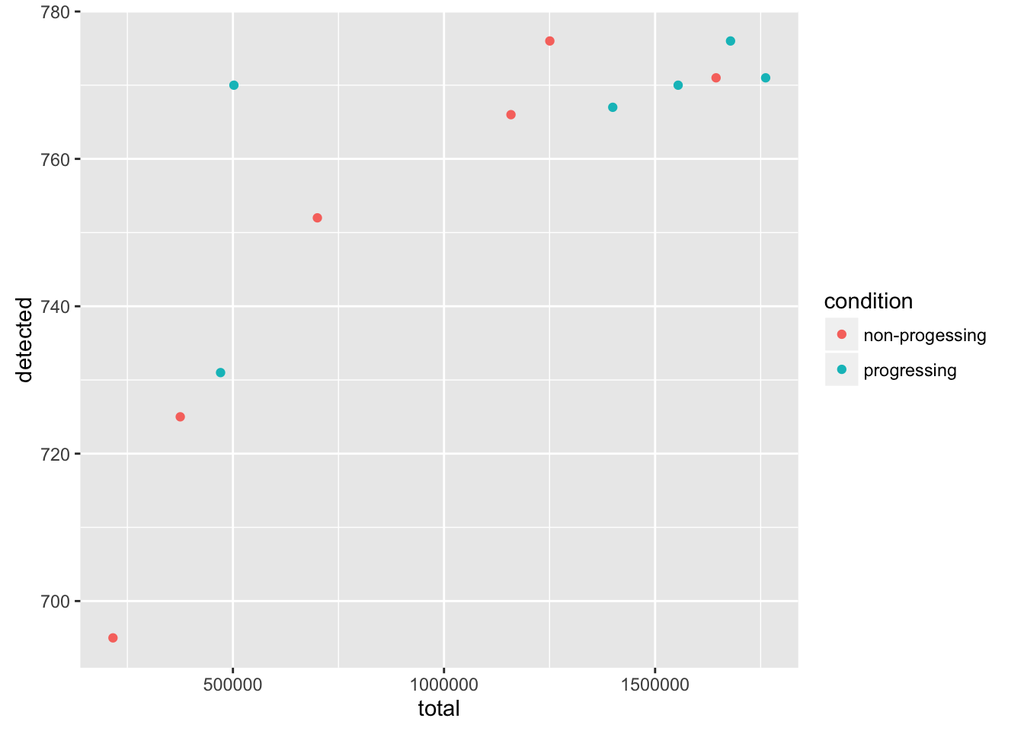

```r
> plotComplexity = function(eset, metadata) {
+     counts = exprs(eset)
+     endocounts = counts[grepl("Endo", rownames(counts)), ]
+     cdf = data.frame(total = colSums(counts), detected = colSums(counts > 10))
+     rownames(cdf) = colnames(counts)
+     cdf$sample = rownames(cdf)
+     cdf = cdf %>% left_join(metadata, by = "sample")
+     ggplot(cdf, aes(total, detected, color = condition)) + geom_point()
+ }
> plotComplexity(eset, metadata)
```

```r
> library(ggplot2)
> library(dplyr)
> library(cowplot)
> is_positive = function(column) {
+     return(grepl("Pos", column))
+ }
> is_negative = function(column) {
+     return(grepl("Neg", column))
+ }
> is_spikein = function(column) {
+     return(grepl("Spike", column))
+ }
> is_ligation = function(column) {
+     return(grepl("Ligati", column))
+ }
> is_housekeeping = function(column) {
+     return(grepl("Housekee", column))
+ }
> is_prior = function(column) {
+     return(grepl("miR-159", column) | grepl("miR-248", column) | grepl("miR-254",
+         column))
+ }
>
> extract_pred = function(eset, predicate, counts = FALSE) {
+     if (!counts) {
+         counts = data.frame(exprs(eset))
+     } else {
+         counts = eset
+     }
+     toplot = counts[predicate(rownames(counts)), ] %>% tibble::rownames_to_column() %>%
+         tidyr::gather("sample", "count", -rowname)
+     colnames(toplot) = c("spot", "sample", "count")
+     toplot = toplot %>% left_join(metadata, by = "sample")
+     return(toplot)
+ }
> spotbarplot = function(toplot) {
+     ggplot(toplot, aes(sample, count, fill = condition)) + geom_bar(stat = "identity") +
+         facet_wrap(~spot) + theme(axis.text.x = element_blank(), text = element_text(size = 8))
+ }
> spotboxplot = function(toplot) {
+     ggplot(toplot, aes(linehypo, count)) + geom_boxplot() + facet_wrap(~spot) +
+         theme(axis.text.x = element_text(angle = 90, hjust = 1))
+ }
```

# Limit of detection

Using the negative controls we can set a limit of detection for the samples. Here we set it to be the mean of the negative control plus 2 SDs.

```r
> lodcounts = extract_pred(eset, is_negative)
> lod = mean(lodcounts$count) + 2 * sd(lodcounts$count)
```

We calculate the LOD as 25.0223743 transcripts.

# Positive controls

Below we look at the R^2 correlation between the expected positive control concentrations and the observed concentrations for each sample. There is no systematic difference between the two conditions, which is good.

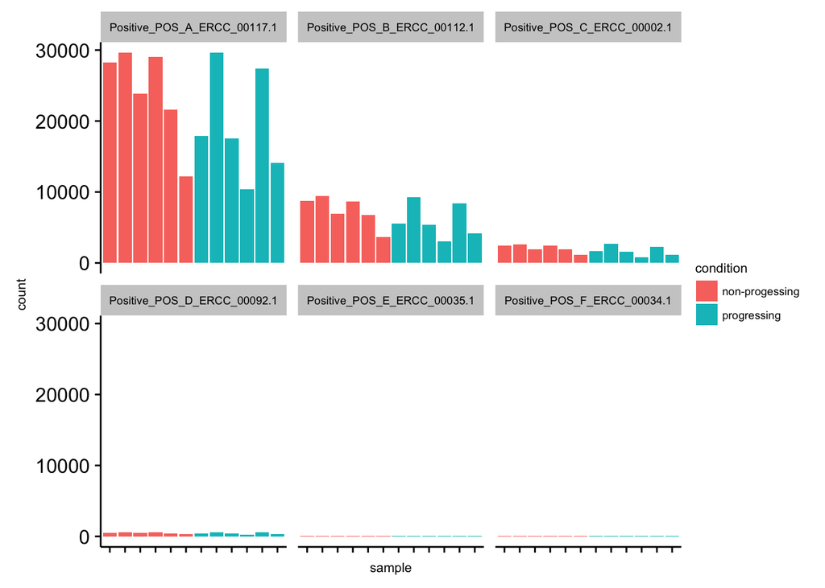

```r
> spotbarplot(extract_pred(eset, is_positive))
```

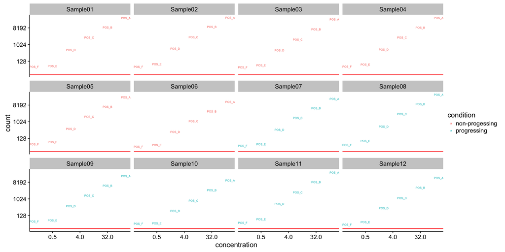

```r
> library(scales)
> pccounts = extract_pred(eset, is_positive)
> pccounts$GeneName = substr(pccounts$spot, 10, 14)
> pcdf = data.frame(concentration = c(128, 32, 8, 2, 0.5, 0.125), GeneName = paste("POS",
+     c("A", "B", "C", "D", "E", "F"), sep = "_"))
> pccounts = pccounts %>% left_join(pcdf, by = "GeneName")
> ggplot(pccounts, aes(concentration, count, color = condition, label = GeneName)) +
+     facet_wrap(~sample) + geom_text(size = 2) + geom_hline(yintercept = lod,
+     show.legend = TRUE, color = "red") + scale_y_continuous(trans = log2_trans()) +
+     scale_x_continuous(trans = log2_trans())
```

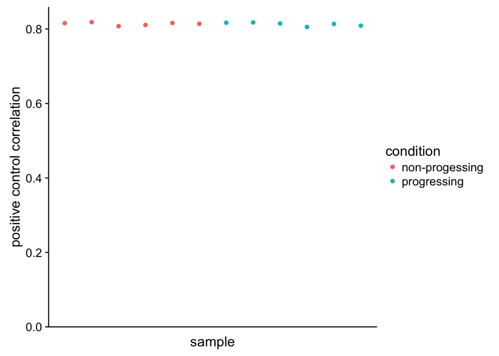

```r
> posR2 = function(eset) {
+     pcdf = data.frame(concentration = log2(c(128, 32, 8, 2, 0.5, 0.125)), GeneName = paste("POS",
+         c("A", "B", "C", "D", "E", "F"), sep = "_"))
+     pccounts = subset(exprs(eset), grepl("Positive_POS", rownames(exprs(eset))))
+     pccounts = pccounts[sort(rownames(pccounts)), ]
+     rownames(pccounts) = pcdf$GeneName
+     corsamples = data.frame(correlation = apply(pccounts, 2, function(x) cor(x,
+         pcdf$concentration)), sample = colnames(pccounts)) %>% left_join(metadata,
+         by = "sample")
+     p = ggplot(corsamples, aes(sample, correlation, color = condition)) + geom_point() +
+         theme(axis.text.x = element_blank(), axis.ticks.x = element_blank(),
+             strip.text.x = element_text(size = 8)) + scale_y_continuous(expand = c(0,
+         0)) + expand_limits(y = c(0, 1.05 * max(corsamples$correlation))) +
+         ylab("positive control correlation") + xlab("sample")
+     print(p)
+     return(corsamples)
+ }
> corsamples = posR2(eset)
```